# Statistical Methods for Data Mining Homework 1

Cloie McClellan

Question 1 asked us to read chapter 2 of The *Elements of Statistical Learning*, which was an introduction to supervised learning.

Question 2 asks us to repeat (with variations) example 3.2.1 from the textbook which is a study of prostate cancer predictors. Here is the description of the data from page 49:

“The data for this example come from a study by Stamey et al. (1989). They examined the correlation between the level of prostate-specific antigen and a number of clinical measures in men who were about to receive a radical prostatectomy. The variables are log cancer volume (lcavol), log prostate weight (lweight), age, log of the amount of benign prostatic hyperplasia (lbph), seminal vesicle invasion (svi), log of capsular penetration (lcp), Gleason score (gleason), and percent of Gleason scores 4 or 5 (pgg45).”

First, we load the appropriate packages and data:

```r
library("ElemStatLearn")
data(prostate)
str( prostate )
```

```
## 'data.frame':    97 obs. of  10 variables:
##  $ lcavol : num  -0.58 -0.994 -0.511 -1.204 0.751 ...
##  $ lweight: num  2.77 3.32 2.69 3.28 3.43 ...
##  $ age    : int  50 58 74 58 62 50 64 58 47 63 ...
##  $ lbph   : num  -1.39 -1.39 -1.39 -1.39 -1.39 ...
##  $ svi    : int  0 0 0 0 0 0 0 0 0 0 ...
##  $ lcp    : num  -1.39 -1.39 -1.39 -1.39 -1.39 ...
##  $ gleason: int  6 6 7 6 6 6 6 6 6 6 ...
##  $ pgg45  : int  0 0 20 0 0 0 0 0 0 0 ...
##  $ lpsa   : num  -0.431 -0.163 -0.163 -0.163 0.372 ...
##  $ train  : logi  TRUE TRUE TRUE TRUE TRUE TRUE ...
```

Next, we create a new split of the data into train and test sets of size 67 and 30 respectively. Once the split is done, we will normalize the sets.

```r
set.seed(101)
sample <- sample.int(n = 97, size = 67, replace = F)
train <- prostate[sample, ]
test  <- prostate[-sample, ]

trainst <- train
for(i in 1:8){
trainst[,i] <- trainst[,i] - mean(prostate[,i]);
trainst[,i] <- trainst[,i]/sd(prostate[,i]);
}

testst<- test
for(i in 1:8){
testst[,i] <- testst[,i] - mean(prostate[,i]);
testst[,i] <- testst[,i]/sd(prostate[,i]);
}
```

```r
# check correlations
cor( prostate[,1:8] )
```

```
##            lcavol   lweight       age         lbph         svi
## lcavol  1.0000000 0.2805214 0.2249999  0.027349703  0.53884500
## lweight 0.2805214 1.0000000 0.3479691  0.442264395  0.15538491
## age     0.2249999 0.3479691 1.0000000  0.350185896  0.11765804
## lbph    0.0273497 0.4422644 0.3501859  1.000000000 -0.08584324
## svi     0.5388450 0.1553849 0.1176580 -0.085843238  1.00000000
## lcp     0.6753105 0.1645371 0.1276678 -0.006999431  0.67311118
## gleason 0.4324171 0.0568821 0.2688916  0.077820447  0.32041222
## pgg45   0.4336522 0.1073538 0.2761124  0.078460018  0.45764762
##                  lcp    gleason      pgg45
## lcavol   0.675310484 0.43241706 0.43365225
## lweight  0.164537146 0.05688210 0.10735379
## age      0.127667752 0.26889160 0.27611245
## lbph    -0.006999431 0.07782045 0.07846002
## svi      0.673111185 0.32041222 0.45764762
## lcp      1.000000000 0.51483006 0.63152825
## gleason  0.514830063 1.00000000 0.75190451
## pgg45    0.631528246 0.75190451 1.00000000
```

```r
# reproduce Table 3.1 on page 50
round(cor( train[,1:8] ),3)
```

```
##         lcavol lweight    age   lbph    svi    lcp gleason  pgg45
## lcavol   1.000   0.191  0.129  0.016  0.441  0.648   0.375  0.366
## lweight  0.191   1.000  0.443  0.473 -0.052 -0.025  -0.027 -0.038
## age      0.129   0.443  1.000  0.365 -0.010  0.023   0.170  0.184
## lbph     0.016   0.473  0.365  1.000 -0.166 -0.058   0.061  0.028
## svi      0.441  -0.052 -0.010 -0.166  1.000  0.530   0.239  0.331
## lcp      0.648  -0.025  0.023 -0.058  0.530  1.000   0.475  0.569
## gleason  0.375  -0.027  0.170  0.061  0.239  0.475   1.000  0.745
## pgg45    0.366  -0.038  0.184  0.028  0.331  0.569   0.745  1.000
```

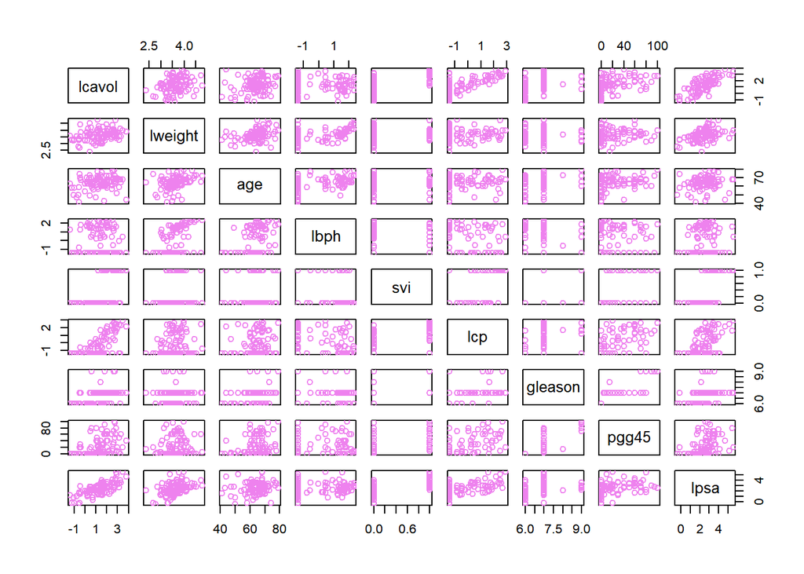

```r
# scatter plot, reproducing Figure 1.1 on page 3
pairs( prostate[,1:9], col="violet" )
```

Now that we have split the data, we first want to find the base error rate. So, we find the mean lpsa value for the train set, and then find the errors given if we simply use this as our prediction for all values.

```r
mean(trainst[,9])
```

```
## [1] 2.531934
```

```r
#mean (absolute) prediction error
mean(abs(testst[,9]-mean(trainst[,9])))
```

```
## [1] 1.009915
```

```r
#mean (squared) prediction error
mean((testst[,9]-mean(trainst[,9]))^2)
```

```
## [1] 1.702432
```

```r
# standard error of mean (squared) prediction error
sd((testst[,9]-mean(trainst[,9]))^2)/sqrt(30)
```

```
## [1] 0.4569091
```

So, the base error rate is 1.7.

Next, we want to fit the whole model to see how it compares:

```r
fitls <- lm( lpsa ~ lcavol+lweight+age+lbph+svi+lcp+gleason+pgg45, data=trainst )
summary(fitls)
```

```
##
## Call:
## lm(formula = lpsa ~ lcavol + lweight + age + lbph + svi + lcp +
##     gleason + pgg45, data = trainst)
##
## Residuals:
##      Min       1Q   Median       3Q      Max
## -1.35389 -0.25076 -0.06273  0.31510  1.40596
##
## Coefficients:
##             Estimate Std. Error t value Pr(>|t|)
## (Intercept)  2.52667    0.07505  33.666  < 2e-16 ***
## lcavol       0.67791    0.10843   6.252 5.21e-08 ***
## lweight      0.33107    0.09684   3.419 0.001157 **
## age         -0.18368    0.08804  -2.086 0.041355 *
## lbph         0.14299    0.08770   1.630 0.108420
## svi          0.38139    0.09460   4.031 0.000164 ***
## lcp         -0.21097    0.12259  -1.721 0.090582 .
## gleason      0.14185    0.11053   1.283 0.204470
## pgg45        0.04553    0.12137   0.375 0.708919
## ---
## Signif. codes:  0 '***' 0.001 '**' 0.01 '*' 0.05 '.' 0.1 ' ' 1
##
## Residual standard error: 0.6079 on 58 degrees of freedom
## Multiple R-squared:  0.7221, Adjusted R-squared:  0.6837
## F-statistic: 18.84 on 8 and 58 DF,  p-value: 1.452e-13
```

```r
test.fitls=predict(fitls, newdata=testst)
# mean (absolute) prediction error
mean(abs(test[,9]-test.fitls))
```

```
## [1] 0.7174125
```

```r
# mean (squared) prediction error
mean((test[,9]-test.fitls)^2)
```

```
## [1] 0.7618813
```

```r
# standard error of mean (squared) prediction error
sd((test[,9]-test.fitls)^2)/sqrt(30)
```

```
## [1] 0.1726857
```

```r
fitlsr <- lm( lpsa ~ lcavol+lweight+lbph+svi, data=trainst )
summary(fitlsr)
```

```
##
## Call:
## lm(formula = lpsa ~ lcavol + lweight + lbph + svi, data = trainst)
##
## Residuals:
##      Min       1Q   Median       3Q      Max
## -1.42401 -0.33698 -0.04458  0.35037  1.40713
##
## Coefficients:
##             Estimate Std. Error t value Pr(>|t|)
## (Intercept)  2.53787    0.07721  32.870  < 2e-16 ***
## lcavol       0.62221    0.09165   6.789 4.97e-09 ***
## lweight      0.26512    0.09269   2.860 0.005758 **
## lbph         0.12308    0.08829   1.394 0.168295
## svi          0.34139    0.09155   3.729 0.000418 ***
## ---
## Signif. codes:  0 '***' 0.001 '**' 0.01 '*' 0.05 '.' 0.1 ' ' 1
##
## Residual standard error: 0.6286 on 62 degrees of freedom
## Multiple R-squared:  0.6824, Adjusted R-squared:  0.6619
## F-statistic:  33.3 on 4 and 62 DF,  p-value: 8.043e-15
```

```r
# mean prediction error based on reduced model
test.fitlsr=predict(fitlsr, newdata=testst)
# mean (absolute) prediction error
mean(abs(test[,9]-test.fitlsr))
```

```
## [1] 0.7022595
```

```r
# mean (squared) prediction error
mean((test[,9]-test.fitlsr)^2)
```

```
## [1] 0.7290343
```

```r
# standard error of mean (squared) prediction error
sd((test[,9]-test.fitlsr)^2)/sqrt(30)
```

```
## [1] 0.1741927
```

The reduced model appears to improve the results. However, we can’t base our analysis purely on this. Instead, we need to look at the F-statistic to decide if we have enough evidence that the coefficience on the removed variables are really zero.

```r
RSSfull<-(.6079)^2*58
RSSred<-(.6286)^2*62
Fstat<-((RSSred-RSSfull)/4)/(RSSfull/58)

Fstat
```

```
## [1] 2.073574
```

From this F-statistic, we get a p-value of .0961 which may or may not be significant depending on the alpha we want to choose. We can see the importance of comparing different train/test splits from this result because it is different than the original split. So, to get a full picture, we want to run the procedure multiple times and compare the results. In this case, multiple will mean 100.

```r
set.seed(102)
bsea=c()
bses=c()
flsea=c()
flses=c()
rlsea=c()
rlses=c()

for(j in 1:100){
sample <- sample.int(n = 97, size = 67, replace = F)
train <- prostate[sample, ]
test  <- prostate[-sample, ]

trainst <- train
for(i in 1:8){
trainst[,i] <- trainst[,i] - mean(prostate[,i]);
trainst[,i] <- trainst[,i]/sd(prostate[,i]);
}

testst<- test
for(i in 1:8){
testst[,i] <- testst[,i] - mean(prostate[,i]);
testst[,i] <- testst[,i]/sd(prostate[,i]);
}

mean(trainst[,9])
#mean (absolute) prediction error
bsea[j]=mean(abs(testst[,9]-mean(trainst[,9])))
#mean (squared) prediction error
bses[j]=mean((testst[,9]-mean(trainst[,9]))^2)

fitls <- lm( lpsa ~ lcavol+lweight+age+lbph+svi+lcp+gleason+pgg45, data=trainst )
summary(fitls)

test.fitls=predict(fitls, newdata=testst)
# mean (absolute) prediction error
flsea[j]=mean(abs(test[,9]-test.fitls))
# mean (squared) prediction error
flses[j]=mean((test[,9]-test.fitls)^2)

fitlsr <- lm( lpsa ~ lcavol+lweight+lbph+svi, data=trainst )
summary(fitlsr)

# mean prediction error based on reduced model
test.fitlsr=predict(fitlsr, newdata=testst)
# mean (absolute) prediction error
rlsea[j]=mean(abs(test[,9]-test.fitlsr))
# mean (squared) prediction error
rlses[j]=mean((test[,9]-test.fitlsr)^2)

}

mean(bsea)
```

```
## [1] 0.9014906
```

```r
mean(bses)
```

```
## [1] 1.358224
```

```r
mean(flsea)
```

```
## [1] 0.5735229
```

```r
mean(flses)
```

```
## [1] 0.573099
```

```r
mean(rlsea)
```

```
## [1] 0.5670725
```

```r
mean(rlses)
```

```
## [1] 0.531232
```

```r
diff=c()
diff=rlses-flses
```

```r
t.test(rlses,flses, paired = TRUE)
```

```
##
##  Paired t-test
##
## data:  rlses and flses
## t = -6.2056, df = 99, p-value = 1.275e-08
## alternative hypothesis: true difference in means is not equal to 0
## 95 percent confidence interval:
##  -0.0552539 -0.0284801
## sample estimates:
## mean of the differences
##               -0.041867
```

So, the paired t-test indicates that, at 95% confidence, there is a difference in the mean for the reduced model and for the full model. This makes a good case that the reduced model is in fact the better. Considering this test based on numerous train/test splits avoids the bias that may be present in one particular choice.